# Chapter 3

Matt Kosko

4/26/2018

Caveat: In all of these questions, we’ll use `ggplot2` rather than R’s base plotting functions.

8. This question involves the use of simple linear regression on the `Auto` data set.
1. Use the `lm()` function to perform a simple linear regression with mpg as the response and horsepower as the predictor. Use the `summary()` function to print the results. Comment on the output. For example:
1. Is there a relationship between the predictor and the response?
2. How strong is the relationship between the predictor and the response?
3. Is the relationship between the predictor and the response positive or negative?
4. What is the predicted mpg associated with a horsepower of 98? What are the associated 95% confidence and prediction intervals?

```r
lm.fit <- lm(mpg~horsepower, data = Auto)
summary(lm.fit)
```

```
##
## Call:
## lm(formula = mpg ~ horsepower, data = Auto)
##
## Residuals:
##      Min       1Q   Median       3Q      Max
## -13.5710  -3.2592  -0.3435   2.7630  16.9240
##
## Coefficients:
##              Estimate Std. Error t value Pr(>|t|)
## (Intercept) 39.935861   0.717499   55.66   <2e-16 ***
## horsepower  -0.157845   0.006446  -24.49   <2e-16 ***
## ---
## Signif. codes:  0 '***' 0.001 '**' 0.01 '*' 0.05 '.' 0.1 ' ' 1
##
## Residual standard error: 4.906 on 390 degrees of freedom
## Multiple R-squared:  0.6059, Adjusted R-squared:  0.6049
## F-statistic: 599.7 on 1 and 390 DF,  p-value: < 2.2e-16
```

There is a negative relationship between horsepower and miles per gallon. Holding all else fixed, a one unit increase in horsepower decreased mpg by 0.16. Calculating the confidence interval, we see that:

```r
conf <- confint(lm.fit)
cat("The 95% confidence interval is ", "[",conf[2,1],",",conf[2,2],"]", sep="")
```

```
## The 95% confidence interval is [-0.170517,-0.1451725]
```

Predicting the mpg at a horsepower of 98, we get:

```r
predicted <- predict(lm.fit,newdata = data.frame(horsepower = 98),interval = 'prediction')
cat("The predicted value is ",predicted[1,1]," and the 95% prediction interval is ", "[",predicted[1,2],",",predicted[1,3],"]", sep="")
```

```
## The predicted value is 24.46708 and the 95% prediction interval is [14.8094,34.12476]
```

2. Plot the response and the predictor. Use the `abline()` function to display the least squares regression line.

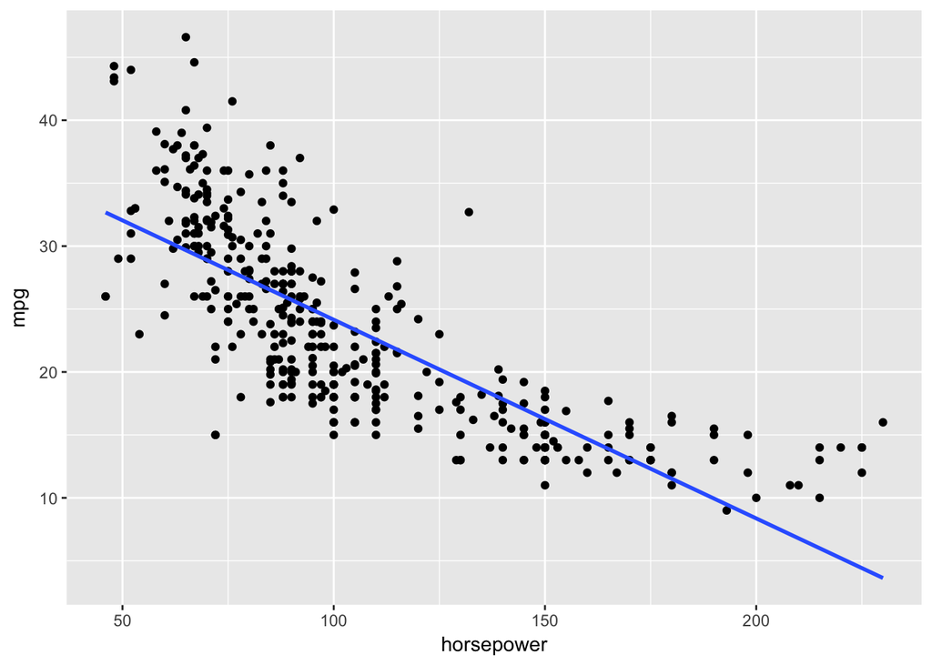

```r
p <- Auto %>% ggplot(aes(x=horsepower,y=mpg))
p + geom_point() + geom_smooth(method='lm',se=F)
```

3. Use the plot() function to produce diagnostic plots of the least squares regression fit. Comment on any problems you see with the fit.

`plot()` applied to an `lm` object returns several charts. We will create a plot of residuals against the fitted values as well as a QQ plot. The residuals vs. fitted values chart can be created by:

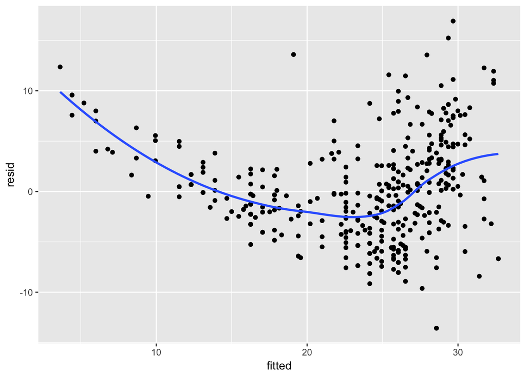

```r
Auto$resid <- lm.fit$residuals
Auto$fitted <- predict(lm.fit)
p %+% Auto + aes(x=fitted,y=resid) + geom_point() + geom_smooth(se=FALSE)
```

The QQ plot is:

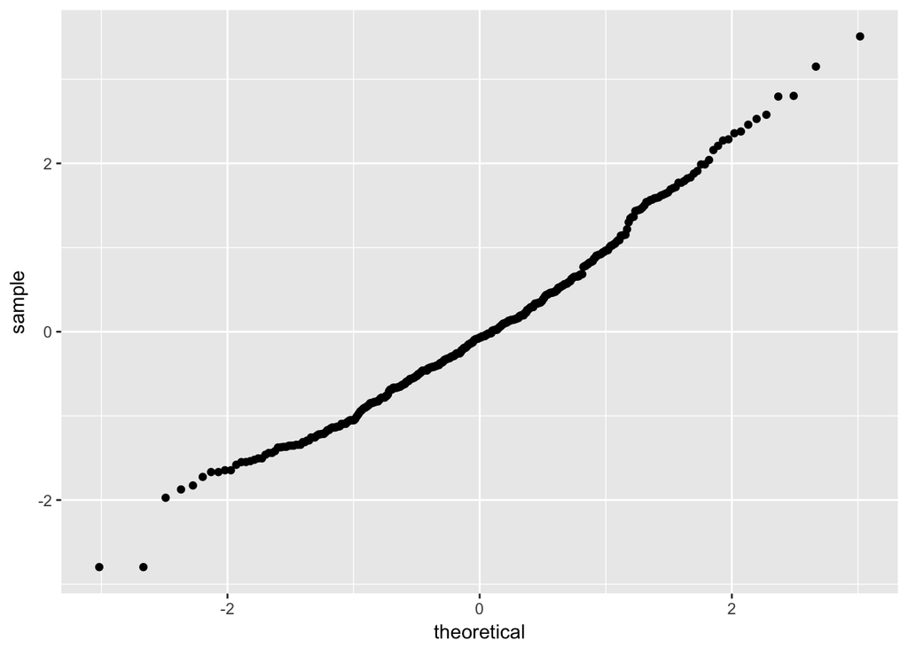

```r
Auto$stures <- studres(lm.fit)
Auto %>% ggplot(aes(sample = stures)) + geom_point(stat='qq')
```

The residuals do not resemble white noise. There appear to be problems with the model at the higher and lower horsepower ranges.

9. This question involves the use of multiple linear regression on the Auto data set.
1. Produce a scatterplot matrix which includes all of the variables in the data set.

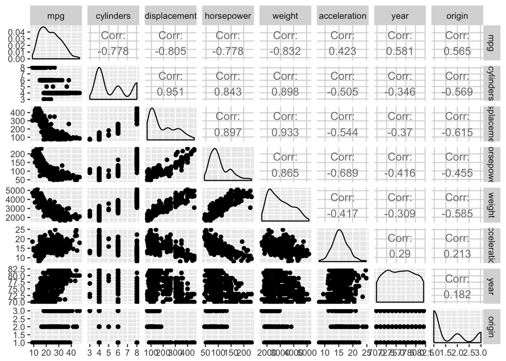

```r
Auto %>% dplyr::select(-c(name,resid,fitted,stures)) %>% ggpairs()
```

2. Compute the matrix of correlations between the variables using the function `cor()`. You will need to exclude the name variable, which is qualitative.

```r
Auto %>% dplyr::select(-c(name,resid,fitted,stures)) %>% cor()
```

```
##                     mpg  cylinders displacement horsepower     weight
## mpg           1.0000000 -0.7776175   -0.8051269 -0.7784268 -0.8322442
## cylinders    -0.7776175  1.0000000    0.9508233  0.8429834  0.8975273
## displacement -0.8051269  0.9508233    1.0000000  0.8972570  0.9329944
## horsepower   -0.7784268  0.8429834    0.8972570  1.0000000  0.8645377
## weight       -0.8322442  0.8975273    0.9329944  0.8645377  1.0000000
## acceleration  0.4233285 -0.5046834   -0.5438005 -0.6891955 -0.4168392
## year          0.5805410 -0.3456474   -0.3698552 -0.4163615 -0.3091199
## origin        0.5652088 -0.5689316   -0.6145351 -0.4551715 -0.5850054
##              acceleration       year     origin
## mpg             0.4233285  0.5805410  0.5652088
## cylinders      -0.5046834 -0.3456474 -0.5689316
## displacement   -0.5438005 -0.3698552 -0.6145351
## horsepower     -0.6891955 -0.4163615 -0.4551715
## weight         -0.4168392 -0.3091199 -0.5850054
## acceleration    1.0000000  0.2903161  0.2127458
## year            0.2903161  1.0000000  0.1815277
## origin          0.2127458  0.1815277  1.0000000
```

3. Use the `lm()` function to perform a multiple linear regression with mpg as the response and all other variables except name as the predictors. Use the `summary()` function to print the results. Comment on the output. For instance:
1. Is there a relationship between the predictors and the response?
2. Which predictors appear to have a statistically significant relationship to the response?
3. What does the coefficient for the year variable suggest?

```r
data(Auto)
lm.out <- lm(mpg ~.-name,data=Auto)
summary(lm.out)
```

```
##
## Call:
## lm(formula = mpg ~ . - name, data = Auto)
##
## Residuals:
##     Min      1Q  Median      3Q     Max
## -9.5903 -2.1565 -0.1169  1.8690 13.0604
##
## Coefficients:
##                Estimate Std. Error t value Pr(>|t|)
## (Intercept)  -17.218435   4.644294  -3.707  0.00024 ***
## cylinders     -0.493376   0.323282  -1.526  0.12780
## displacement   0.019896   0.007515   2.647  0.00844 **
## horsepower    -0.016951   0.013787  -1.230  0.21963
## weight        -0.006474   0.000652  -9.929  < 2e-16 ***
## acceleration   0.080576   0.098845   0.815  0.41548
## year           0.750773   0.050973  14.729  < 2e-16 ***
## origin         1.426141   0.278136   5.127 4.67e-07 ***
## ---
## Signif. codes:  0 '***' 0.001 '**' 0.01 '*' 0.05 '.' 0.1 ' ' 1
##
## Residual standard error: 3.328 on 384 degrees of freedom
## Multiple R-squared:  0.8215, Adjusted R-squared:  0.8182
## F-statistic: 252.4 on 7 and 384 DF,  p-value: < 2.2e-16
```

The F-statistic leads us to reject the null of all zero coefficients. The displacement, weight, year, and origin predictors have a statistically significant effect on the response. The year variable suggests that a one year decrease in the age of a car increases mpg by 0.75.

4. Use the `plot()` function to produce diagnostic plots of the linear regression fit. Comment on any problems you see with the fit. Do the residual plots suggest any unusually large outliers? Does the leverage plot identify any observations with unusually high leverage?

```r
Auto$resid <- lm.out$residuals
Auto$fitted <- predict(lm.out)
Auto$stures <- studres(lm.out)
Auto$leverage <- hatvalues(lm.out)
```

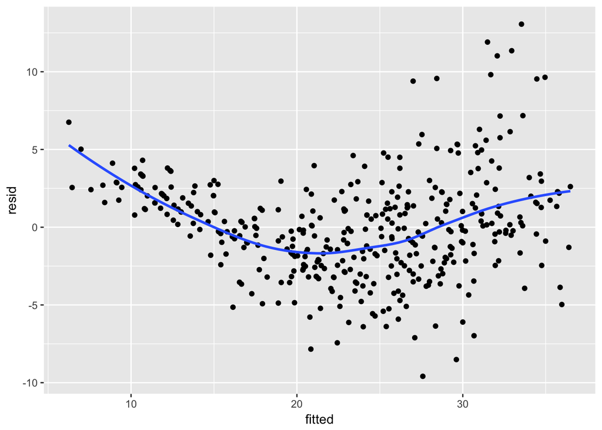

```r
Auto %>% ggplot(aes(x=fitted,y=resid)) + geom_point() + geom_smooth(se=F)
```

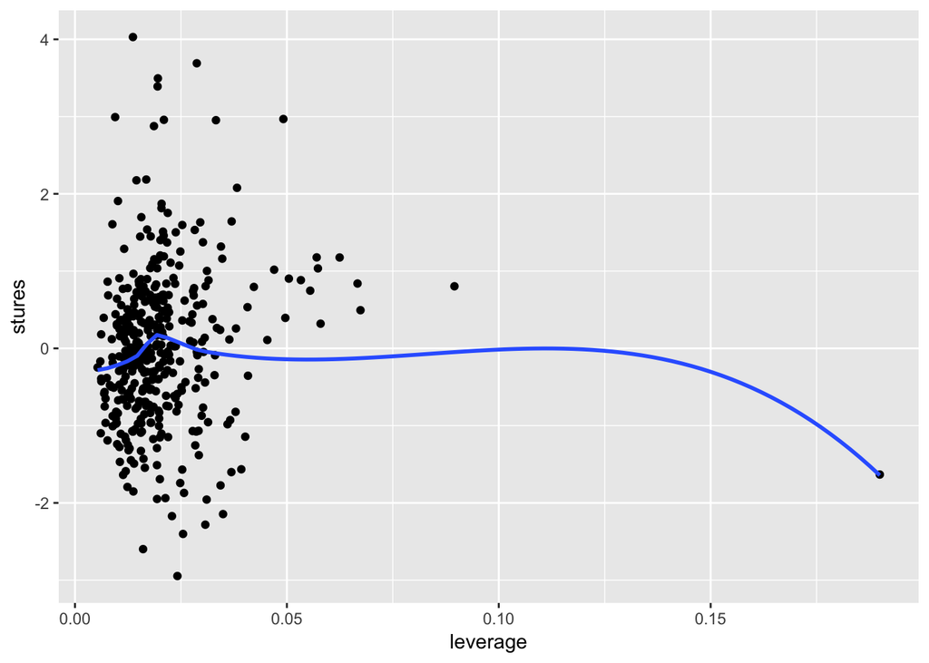

```r
Auto %>% ggplot(aes(x=leverage,y=stures)) + geom_point() + geom_smooth(se=F)
```

5. Use the * and : symbols to fit linear regression models with interaction effects. Do any interactions appear to be statistically significant?

```r
data(Auto)
Auto <- Auto %>% dplyr::select(-name)
lm.out <- lm(mpg ~.*.,data=Auto)
summary(lm.out)
```

```
##
## Call:
## lm(formula = mpg ~ . * ., data = Auto)
##
## Residuals:
##     Min      1Q  Median      3Q     Max
## -7.6303 -1.4481  0.0596  1.2739 11.1386
##
## Coefficients:
##                             Estimate Std. Error t value Pr(>|t|)
## (Intercept)                3.548e+01  5.314e+01   0.668  0.50475
## cylinders                  6.989e+00  8.248e+00   0.847  0.39738
## displacement              -4.785e-01  1.894e-01  -2.527  0.01192 *
## horsepower                 5.034e-01  3.470e-01   1.451  0.14769
## weight                     4.133e-03  1.759e-02   0.235  0.81442
## acceleration              -5.859e+00  2.174e+00  -2.696  0.00735 **
## year                       6.974e-01  6.097e-01   1.144  0.25340
## origin                    -2.090e+01  7.097e+00  -2.944  0.00345 **
## cylinders:displacement    -3.383e-03  6.455e-03  -0.524  0.60051
## cylinders:horsepower       1.161e-02  2.420e-02   0.480  0.63157
## cylinders:weight           3.575e-04  8.955e-04   0.399  0.69000
## cylinders:acceleration     2.779e-01  1.664e-01   1.670  0.09584 .
## cylinders:year            -1.741e-01  9.714e-02  -1.793  0.07389 .
## cylinders:origin           4.022e-01  4.926e-01   0.816  0.41482
## displacement:horsepower   -8.491e-05  2.885e-04  -0.294  0.76867
## displacement:weight        2.472e-05  1.470e-05   1.682  0.09342 .
## displacement:acceleration -3.479e-03  3.342e-03  -1.041  0.29853
## displacement:year          5.934e-03  2.391e-03   2.482  0.01352 *
## displacement:origin        2.398e-02  1.947e-02   1.232  0.21875
## horsepower:weight         -1.968e-05  2.924e-05  -0.673  0.50124
## horsepower:acceleration   -7.213e-03  3.719e-03  -1.939  0.05325 .
## horsepower:year           -5.838e-03  3.938e-03  -1.482  0.13916
## horsepower:origin          2.233e-03  2.930e-02   0.076  0.93931
## weight:acceleration        2.346e-04  2.289e-04   1.025  0.30596
## weight:year               -2.245e-04  2.127e-04  -1.056  0.29182
## weight:origin             -5.789e-04  1.591e-03  -0.364  0.71623
## acceleration:year          5.562e-02  2.558e-02   2.174  0.03033 *
## acceleration:origin        4.583e-01  1.567e-01   2.926  0.00365 **
## year:origin                1.393e-01  7.399e-02   1.882  0.06062 .
## ---
## Signif. codes:  0 '***' 0.001 '**' 0.01 '*' 0.05 '.' 0.1 ' ' 1
##
## Residual standard error: 2.695 on 363 degrees of freedom
## Multiple R-squared:  0.8893, Adjusted R-squared:  0.8808
## F-statistic: 104.2 on 28 and 363 DF,  p-value: < 2.2e-16
```

10. This question should be answered using the `Carseats` data set.
1. Fit a multiple regression model to predict Sales using Price, Urban, and US.

```r
data(Carseats)
lm.out <- lm(Sales ~ Price + Urban + US, data = Carseats)
summary(lm.out)
```

```
##
## Call:
## lm(formula = Sales ~ Price + Urban + US, data = Carseats)
##
## Residuals:
##     Min      1Q  Median      3Q     Max
## -6.9206 -1.6220 -0.0564  1.5786  7.0581
##
## Coefficients:
##              Estimate Std. Error t value Pr(>|t|)
## (Intercept) 13.043469   0.651012  20.036  < 2e-16 ***
## Price       -0.054459   0.005242 -10.389  < 2e-16 ***
## UrbanYes    -0.021916   0.271650  -0.081    0.936
## USYes        1.200573   0.259042   4.635 4.86e-06 ***
## ---
## Signif. codes:  0 '***' 0.001 '**' 0.01 '*' 0.05 '.' 0.1 ' ' 1
##
## Residual standard error: 2.472 on 396 degrees of freedom
## Multiple R-squared:  0.2393, Adjusted R-squared:  0.2335
## F-statistic: 41.52 on 3 and 396 DF,  p-value: < 2.2e-16
```

2. Provide an interpretation of each coefficient in the model. Be careful—some of the variables in the model are qualitative!

(Holding all else constant) a $1 increase in price is associated with a 0.05 unit reduction in sales. Urban areas are associated with a decrease in sales, while being located in the US increases sales.

3. Write out the model in equation form, being careful to handle the qualitative variables properly.

$$sales = \beta_0 + \beta_1Price + \beta_2Urban + \beta_3US$$

4. For which of the predictors can you reject the null hypothesis $H0 :\beta_j =0$?

We can reject the null for Price and US.

5. On the basis of your response to the previous question, fit a smaller model that only uses the predictors for which there is evidence of association with the outcome.

```r
lm.out2 <-update(lm.out,.~.-Urban)
summary(lm.out2)
```

```
##
## Call:
## lm(formula = Sales ~ Price + US, data = Carseats)
##
## Residuals:
##     Min      1Q  Median      3Q     Max
## -6.9269 -1.6286 -0.0574  1.5766  7.0515
##
## Coefficients:
##             Estimate Std. Error t value Pr(>|t|)
## (Intercept) 13.03079    0.63098  20.652  < 2e-16 ***
## Price       -0.05448    0.00523 -10.416  < 2e-16 ***
## USYes        1.19964    0.25846   4.641 4.71e-06 ***
## ---
## Signif. codes:  0 '***' 0.001 '**' 0.01 '*' 0.05 '.' 0.1 ' ' 1
##
## Residual standard error: 2.469 on 397 degrees of freedom
## Multiple R-squared:  0.2393, Adjusted R-squared:  0.2354
## F-statistic: 62.43 on 2 and 397 DF,  p-value: < 2.2e-16
```

6. How well do the models in (a) and (e) fit the data?

Model (e) fits the data betters on the basis of adjusted $R^2$. Moreover,

```r
cat("On the basis of AIC, ",ifelse(AIC(lm.out)<AIC(lm.out2),"model (a)","model (e)")," fits the data better",sep='')
```

```
## On the basis of AIC, model (e) fits the data better
```

7. Using the model from (e), obtain 95% confidence intervals for the coefficient(s).

```r
confint(lm.out2)
```

```
##                   2.5 %      97.5 %
## (Intercept) 11.79032020 14.27126531
## Price       -0.06475984 -0.04419543
## USYes        0.69151957  1.70776632
```

8. Is there evidence of outliers or high leverage observations in the model from (e)?

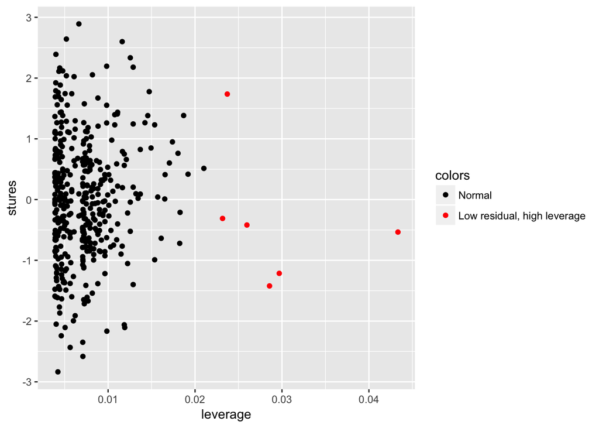

```r
Carseats$stures <- studres(lm.out2)
Carseats$leverage <- hatvalues(lm.out2)
p_1 <- length(coef(lm.out2))
n <- dim(Carseats)[1]
Carseats$colors <- 'regular'
Carseats[abs(Carseats$stures)>3 & Carseats$leverage > 3*p_1/n,'colors'] <- 'HRHL'
Carseats[!abs(Carseats$stures)>3 & Carseats$leverage > 3*p_1/n,'colors'] <- 'LRHL'
Carseats[abs(Carseats$stures)>3 & !Carseats$leverage > 3*p_1/n,'colors'] <- 'HRLL'
cols <- c('regular'='black','HRHL'='orange','LRHL'='red','HRLL'='blue')
Carseats %>% ggplot(aes(x=leverage,y=stures,colour=colors)) + geom_point() + scale_color_manual(values=cols,breaks=c('regular','HRHL','LRHL','HRLL'),                                                             labels=c('Normal','High residual, high leverage','Low residual, high leverage','High residual, low leverage'))
```

Using studentized residuals greater than 3 in absolute value as the measure of an outlier, there are no outliers in the data. However, there are several points that have leverage greater than 3 times the average leverage value, $\dfrac{p+1}{n}$, where $p$ is the number of predictors.

11. In this problem we will investigate the t-statistic for the null hypothesis $H_0 : \beta = 0$ in simple linear regression without an intercept. To begin, we generate a predictor $x$ and a response y as follows.

```r
set.seed(1)
x=rnorm(100)
y=x+rnorm(100)
```

1. Perform a simple linear regression of $y$ onto $x$, without an intercept. Report the coefficient estimate $\hat{\beta}$, the standard error of this coefficient estimate, and the t-statistic and p-value associated with the null hypothesis $H_0 : \beta = 0$. Comment on these results. (You can perform regression without an intercept using the command `lm(y∼x+0)`.)

```r
lm.out <- lm(y~x-1)
summary(lm.out)
```

```
##
## Call:
## lm(formula = y ~ x - 1)
##
## Residuals:
##     Min      1Q  Median      3Q     Max
## -1.9154 -0.6472 -0.1771  0.5056  2.3109
##
## Coefficients:
##   Estimate Std. Error t value Pr(>|t|)
## x   0.9939     0.1065   9.334  3.1e-15 ***
## ---
## Signif. codes:  0 '***' 0.001 '**' 0.01 '*' 0.05 '.' 0.1 ' ' 1
##
## Residual standard error: 0.9586 on 99 degrees of freedom
## Multiple R-squared:  0.4681, Adjusted R-squared:  0.4627
## F-statistic: 87.13 on 1 and 99 DF,  p-value: 3.1e-15
```

2. Now perform a simple linear regression of $x$ onto $y$ without an intercept, and report the coefficient estimate, its standard error, and the corresponding t-statistic and p-values associated with the null hypothesis $H_0 : \beta = 0$. Comment on these results.

```r
lm.out2 <- lm(x~y-1)
summary(lm.out2)
```

```
##
## Call:
## lm(formula = x ~ y - 1)
##
## Residuals:
##      Min       1Q   Median       3Q      Max
## -1.35410 -0.37468  0.09974  0.48799  1.55406
##
## Coefficients:
##   Estimate Std. Error t value Pr(>|t|)
## y  0.47099    0.05046   9.334  3.1e-15 ***
## ---
## Signif. codes:  0 '***' 0.001 '**' 0.01 '*' 0.05 '.' 0.1 ' ' 1
##
## Residual standard error: 0.6599 on 99 degrees of freedom
## Multiple R-squared:  0.4681, Adjusted R-squared:  0.4627
## F-statistic: 87.13 on 1 and 99 DF,  p-value: 3.1e-15
```

6. In `R`, show that when regression is performed with an intercept, the t-statistic for $H_0 : \beta_1 = 0$ is the same for the regression of $y$ onto $x$ as it is for the regression of $x$ onto $y$.

```r
lm.out <- lm(y~x)
lm.out2 <- lm(x~y)
sum1 <- summary(lm.out)
sum2 <- summary(lm.out2)
cat("The t-statistic for the regression of y on x is ",round(coef(sum1)[2,1]/coef(sum1)[2,2],3)," while the t-statistic for the regression of x on y is ",round(coef(sum2)[2,1]/coef(sum2)[2,2],3)," which are the same.",sep='')
```

```
## The t-statistic for the regression of y on x is 9.273 while the t-statistic for the regression of x on y is 9.273 which are the same.
```

12. This problem involves simple linear regression without an intercept.
1. Recall that the coefficient estimate $\hat{\beta}$ for the linear regression of Y onto X without an intercept is given by (3.38). Under what circumstance is the coefficient estimate for the regression of X onto Y the same as the coefficient estimate for the regression of Y onto X?

See part (b)

2. Generate an example in R with n = 100 observations in which the coefficient estimate for the regression of X onto Y is different from the coefficient estimate for the regression of Y onto X.

For a simple linear regression with no intercept of y on x, the coefficient is given by:
$$\hat{\beta} = \dfrac{\sum x_iy_i}{\sum x_i^2}$$
For a simple regression of x on y with no intercept, these estimates will be the same if the uncentered samplevariance is the same. We can get this by standardizing the variables before regressing.

```r
set.seed(123)
x = rnorm(100)
y = x+ rnorm(100)
st_y = (y-mean(y))/sd(y)
st_x = (x-mean(x))/sd(x)
lm.out <- lm(st_y~st_x-1)
lm.out2 <- lm(st_x~st_y-1)
sum1 <- summary(lm.out)
sum2 <- summary(lm.out2)
cat("The coefficient in the regression of y on x is ",coef(sum1)[1]," and the coefficient in the regression of x on y is ",coef(sum2)[1],sep='')
```

```
## The coefficient in the regression of y on x is 0.66713 and the coefficient in the regression of x on y is 0.66713
```

In order to get variables that don’t have the same coefficient, we simply generate and don’t standardize.

```r
set.seed(123)
x = rnorm(100)
y = x+ rnorm(100)
lm.out <- lm(y~x-1)
lm.out2 <- lm(x~y-1)
sum1 <- summary(lm.out)
sum2 <- summary(lm.out2)
cat("The coefficient in the regression of y on x is ",coef(sum1)[1]," and the coefficient in the regression of x on y is ",coef(sum2)[1],sep='')
```

```
## The coefficient in the regression of y on x is 0.9363721 and the coefficient in the regression of x on y is 0.4686948
```

3. Generate an example in R with n = 100 observations in which the coefficient estimate for the regression of X onto Y is the same as the coefficient estimate for the regression of Y onto X.

See part (b).

13. In this exercise you will create some simulated data and will fit simple linear regression models to it. Make sure to use `set.seed(1)` prior to starting part (a) to ensure consistent results.
1. Using the `rnorm()` function, create a vector, x, containing 100 observations drawn from a $N(0, 1)$ distribution. This represents a feature, X.

```r
set.seed(1)
x <- rnorm(100)
```

2. Using the `rnorm()` function, create a vector, `eps`, containing 100 observations drawn from a $N(0,0.25)$ distribution i.e. a normal distribution with mean zero and variance 0.25.

```r
eps <- rnorm(100,0,0.25)
```

3. Using x and eps, generate a vector y according to the model
   $$Y =−1+0.5X+\epsilon$$
   What is the length of the vector y? What are the values of $\beta_0$ and $\beta_1$ in this linear model?

```r
y <- -1 + 0.5*x+eps
```

4. Create a scatterplot displaying the relationship between x and y. Comment on what you observe.

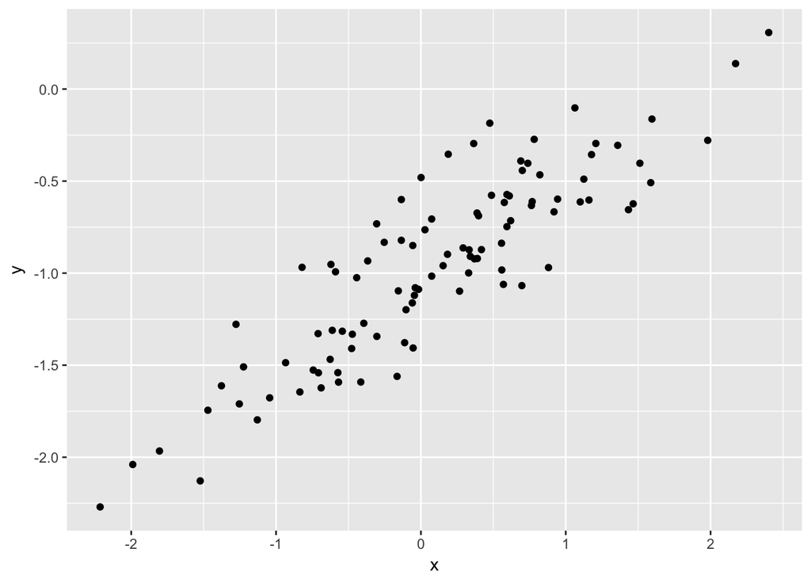

```r
df <- data.frame(x=x,y=y)
p <- ggplot(df,aes(x=x,y=y))
p + geom_point()
```

Unsurprisingly, there appears to be a strong, positive linear relationship between x and y.

5. Fit a least squares linear model to predict y using x. Comment on the model obtained. How do $\hat{\beta_0}$ and $\hat{\beta_1}$ compare to $\beta_0$ and $\beta_1$?

```r
lm.out <- lm(y~x)
summary(lm.out)
```

```
##
## Call:
## lm(formula = y ~ x)
##
## Residuals:
##      Min       1Q   Median       3Q      Max
## -0.46921 -0.15344 -0.03487  0.13485  0.58654
##
## Coefficients:
##             Estimate Std. Error t value Pr(>|t|)
## (Intercept) -1.00942    0.02425  -41.63   <2e-16 ***
## x            0.49973    0.02693   18.56   <2e-16 ***
## ---
## Signif. codes:  0 '***' 0.001 '**' 0.01 '*' 0.05 '.' 0.1 ' ' 1
##
## Residual standard error: 0.2407 on 98 degrees of freedom
## Multiple R-squared:  0.7784, Adjusted R-squared:  0.7762
## F-statistic: 344.3 on 1 and 98 DF,  p-value: < 2.2e-16
```

The estimated coefficients are very similar to the true values.

6. Display the least squares line on the scatterplot obtained in (d). Draw the population regression line on the plot, in a different color. Use the `legend()` command to create an appropriate legend.

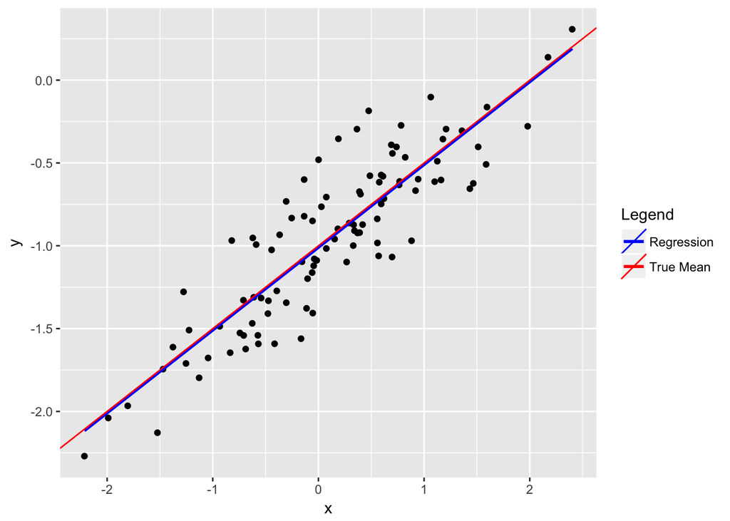

```r
p + geom_point() + geom_smooth(method = 'lm',se=F,aes(color='Regression')) + geom_abline(aes(color='True Mean',intercept=-1,slope=0.5)) +scale_colour_manual(name="Legend", values=c("blue",'red'))
```

7. Now fit a polynomial regression model that predicts y using x and $x^2$. Is there evidence that the quadratic term improves the model fit? Explain your answer.

```r
lm.out2 <- lm(y~x + I(x^2))
summary(lm.out2)
```

```
##
## Call:
## lm(formula = y ~ x + I(x^2))
##
## Residuals:
##     Min      1Q  Median      3Q     Max
## -0.4913 -0.1563 -0.0322  0.1451  0.5675
##
## Coefficients:
##             Estimate Std. Error t value Pr(>|t|)
## (Intercept) -0.98582    0.02941 -33.516   <2e-16 ***
## x            0.50429    0.02700  18.680   <2e-16 ***
## I(x^2)      -0.02973    0.02119  -1.403    0.164
## ---
## Signif. codes:  0 '***' 0.001 '**' 0.01 '*' 0.05 '.' 0.1 ' ' 1
##
## Residual standard error: 0.2395 on 97 degrees of freedom
## Multiple R-squared:  0.7828, Adjusted R-squared:  0.7784
## F-statistic: 174.8 on 2 and 97 DF,  p-value: < 2.2e-16
```

The coefficient on the square term is not significant. Adding the polynomial term does not appear to improve the fit, however the adjusted $R^2$ does increase.

8. Repeat (a)–(f) after modifying the data generation process in such a way that there is less noise in the data. The model (3.39) should remain the same. You can do this by decreasing the variance of the normal distribution used to generate the error term $\epsilon$ in (b). Describe your results.

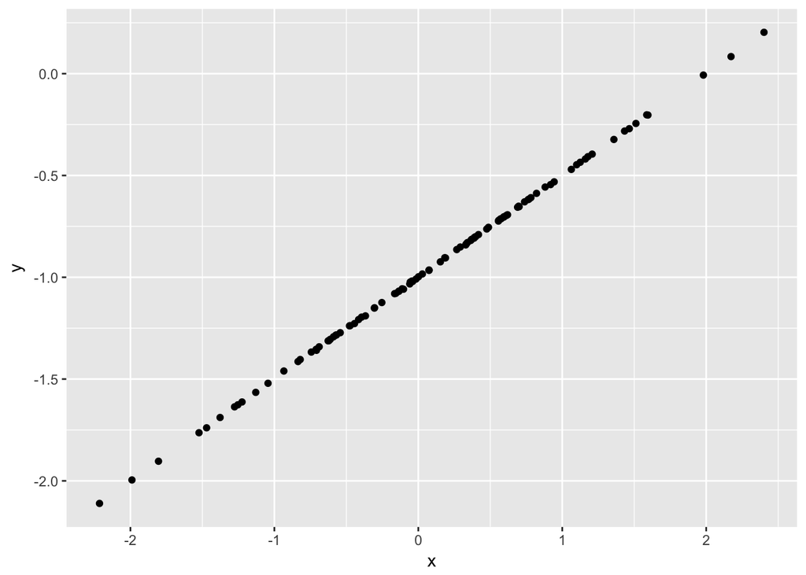

```r
eps <- rnorm(100,0,0.0025)
y <- -1 + 0.5*x+eps
df <- data.frame(x=x,y=y)
p <- ggplot(df,aes(x=x,y=y))
p + geom_point()
```

```r
lm.out3 <- lm(y~x)
summary(lm.out3)
```

```
##
## Call:
## lm(formula = y ~ x)
##
## Residuals:
##        Min         1Q     Median         3Q        Max
## -0.0072853 -0.0012058 -0.0001133  0.0016231  0.0066039
##
## Coefficients:
##               Estimate Std. Error t value Pr(>|t|)
## (Intercept) -0.9999316  0.0002618   -3820   <2e-16 ***
## x            0.5000529  0.0002907    1720   <2e-16 ***
## ---
## Signif. codes:  0 '***' 0.001 '**' 0.01 '*' 0.05 '.' 0.1 ' ' 1
##
## Residual standard error: 0.002598 on 98 degrees of freedom
## Multiple R-squared:      1,  Adjusted R-squared:      1
## F-statistic: 2.958e+06 on 1 and 98 DF,  p-value: < 2.2e-16
```

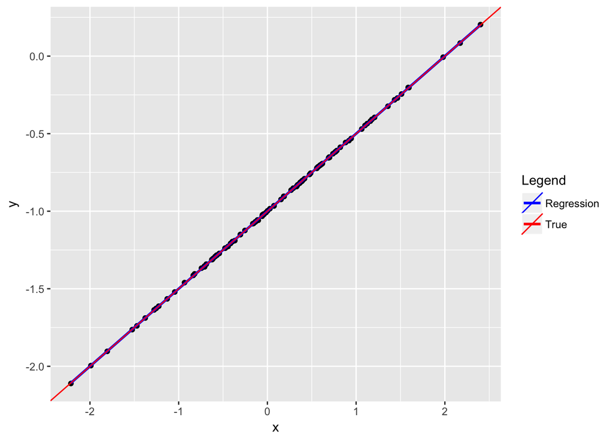

```r
p + geom_point() + geom_smooth(method = 'lm',se=F,aes(color='Regression')) + geom_abline(aes(color='True',intercept=-1,slope=0.5)) +scale_colour_manual(name="Legend", values=c("blue",'red'))
```

The regression and true mean lines are indistinguishable.

1. Repeat (a)–(f) after modifying the data generation process in such a way that there is more noise in the data. The model (3.39) should remain the same. You can do this by increasing the variance of the normal distribution used to generate the error term $\epsilon$ in (b). Describe your results.

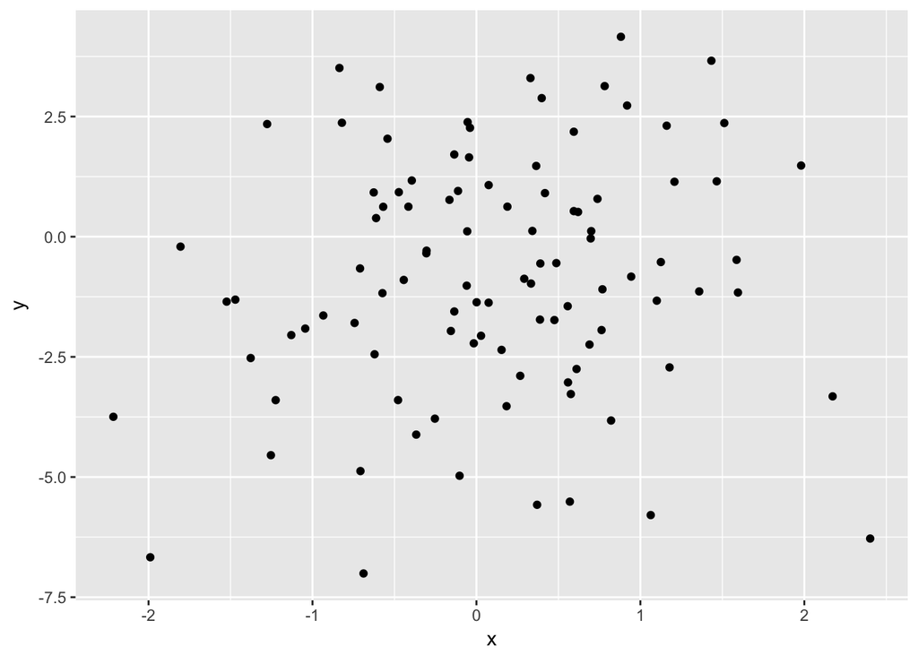

```r
eps <- rnorm(100,0,2.5)
y <- -1 + 0.5*x+eps
df <- data.frame(x=x,y=y)
p <- ggplot(df,aes(x=x,y=y))
p + geom_point()
```

```r
lm.out4 <- lm(y~x)
summary(lm.out4)
```

```
##
## Call:
## lm(formula = y ~ x)
##
## Residuals:
##     Min      1Q  Median      3Q     Max
## -6.2906 -1.3631 -0.0944  1.6822  4.6972
##
## Coefficients:
##             Estimate Std. Error t value Pr(>|t|)
## (Intercept)  -0.8558     0.2507  -3.414 0.000933 ***
## x             0.3608     0.2785   1.296 0.198150
## ---
## Signif. codes:  0 '***' 0.001 '**' 0.01 '*' 0.05 '.' 0.1 ' ' 1
##
## Residual standard error: 2.489 on 98 degrees of freedom
## Multiple R-squared:  0.01684,    Adjusted R-squared:  0.006808
## F-statistic: 1.679 on 1 and 98 DF,  p-value: 0.1981
```

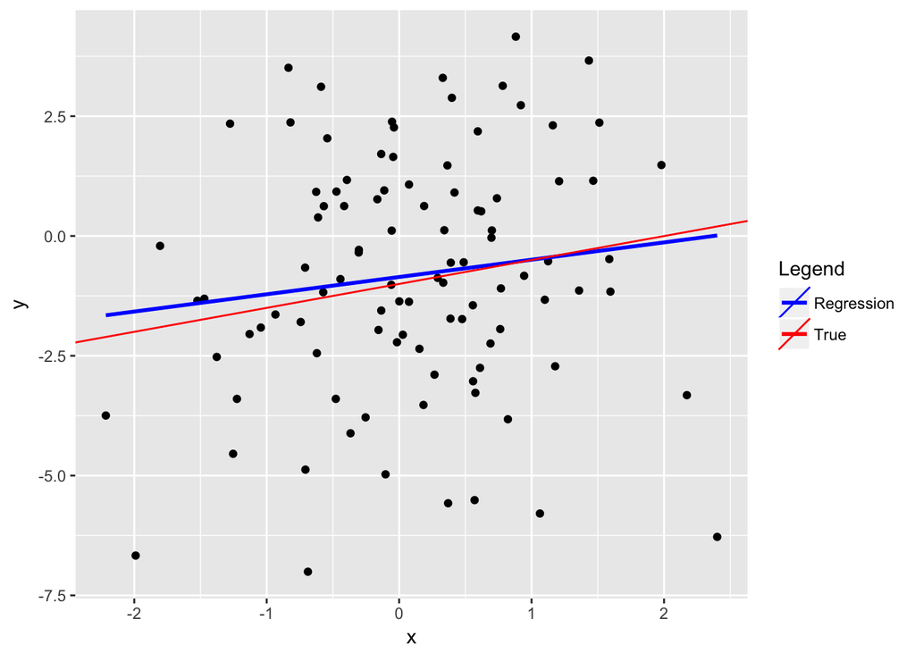

```r
p + geom_point() + geom_smooth(method = 'lm',se=F,aes(color='Regression')) + geom_abline(aes(color='True',intercept=-1,slope=0.5)) +scale_colour_manual(name="Legend", values=c("blue",'red'))
```

The $x$ term is no longer significant in the high noise model. The noise overwhelms the underlying mean function.

10. What are the confidence intervals for $\beta_0$ and $\beta_1$ based on the original data set, the noisier data set, and the less noisy data set? Comment on your results.

```r
print(confint(lm.out))
```

```
##                  2.5 %     97.5 %
## (Intercept) -1.0575402 -0.9613061
## x            0.4462897  0.5531801
```

```r
print(confint(lm.out3))
```

```
##                  2.5 %     97.5 %
## (Intercept) -1.0004510 -0.9994121
## x            0.4994759  0.5006299
```

```r
print(confint(lm.out4))
```

```
##                  2.5 %     97.5 %
## (Intercept) -1.3533499 -0.3583233
## x           -0.1918198  0.9133895
```

In the high noise case, the confidence interval does not exclude zero.

14. This problem focuses on the collinearity problem.
1. Perform the following commands in R:

```r
set.seed(1)
x1=runif(100)
x2=0.5*x1+rnorm(100)/10
y=2+2*x1+0.3*x2+rnorm(100)
```

The last line corresponds to creating a linear model in which $y$ is a function of $x_1$ and $x_2$. Write out the form of the linear model. What are the regression coefficients?

The linear model is of the form:

$$y = \beta_0 + \beta_1x_1 + \beta_2 x_2 + \epsilon$$
where $\beta_0 = 2$, $\beta_1 =2$, $\beta_2 = 0.3$, and $\epsilon \sim N(0,1)$.

2. What is the correlation between x1 and x2? Create a scatterplot displaying the relationship between the variables.

```r
print(cor(x1,x2))
```

```
## [1] 0.8351212
```

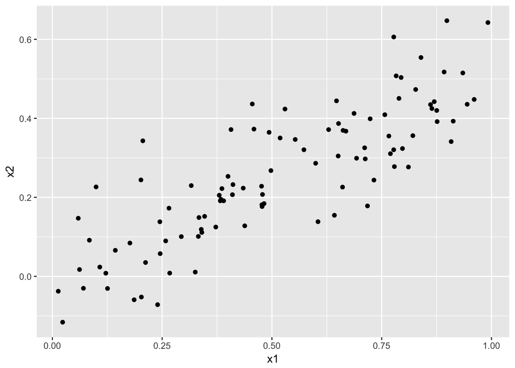

```r
df <- data.frame(y=y,x1=x1,x2=x2)
ggplot(df, aes(x=x1,y=x2)) + geom_point()
```

3. Using this data, fit a least squares regression to predict y using $x_1$ and $x_2$. Describe the results obtained. What are $\hat{\beta_0}$, $\hat{\beta_1}$, and $\hat{\beta_2}$? How do these relate to the true $\beta_0$, $\beta_1$, and $\beta_2$? Can you reject the null hypothesis $H_0 : \beta_1 = 0$? How about the null hypothesis $H_0 : \beta_2 = 0$?

```r
lm.out <- lm(y~x1 + x2)
summary(lm.out)
```

```
##
## Call:
## lm(formula = y ~ x1 + x2)
##
## Residuals:
##     Min      1Q  Median      3Q     Max
## -2.8311 -0.7273 -0.0537  0.6338  2.3359
##
## Coefficients:
##             Estimate Std. Error t value Pr(>|t|)
## (Intercept)   2.1305     0.2319   9.188 7.61e-15 ***
## x1            1.4396     0.7212   1.996   0.0487 *
## x2            1.0097     1.1337   0.891   0.3754
## ---
## Signif. codes:  0 '***' 0.001 '**' 0.01 '*' 0.05 '.' 0.1 ' ' 1
##
## Residual standard error: 1.056 on 97 degrees of freedom
## Multiple R-squared:  0.2088, Adjusted R-squared:  0.1925
## F-statistic:  12.8 on 2 and 97 DF,  p-value: 1.164e-05
```

| Coefficient | True Value | Estimated Value |
| --- | --- | --- |
| $\beta_0$ | 2 | 2.13 |
| $\beta_1$ | 2 | 1.44 |
| $\beta_2$ | 0.3 | 1.01 |

4. Now fit a least squares regression to predict y using only x1. Comment on your results. Can you reject the null hypothesis $H_0 :\beta_1 =0$?

```r
summary(lm(y~x1))
```

```
##
## Call:
## lm(formula = y ~ x1)
##
## Residuals:
##      Min       1Q   Median       3Q      Max
## -2.89495 -0.66874 -0.07785  0.59221  2.45560
##
## Coefficients:
##             Estimate Std. Error t value Pr(>|t|)
## (Intercept)   2.1124     0.2307   9.155 8.27e-15 ***
## x1            1.9759     0.3963   4.986 2.66e-06 ***
## ---
## Signif. codes:  0 '***' 0.001 '**' 0.01 '*' 0.05 '.' 0.1 ' ' 1
##
## Residual standard error: 1.055 on 98 degrees of freedom
## Multiple R-squared:  0.2024, Adjusted R-squared:  0.1942
## F-statistic: 24.86 on 1 and 98 DF,  p-value: 2.661e-06
```

We can reject the null and the result is close to the true value.

5. Now fit a least squares regression to predict y using only x2. Comment on your results. Can you reject the null hypothesis $H_0 :\beta_1 =0$?

```r
summary(lm(y~x2))
```

```
##
## Call:
## lm(formula = y ~ x2)
##
## Residuals:
##      Min       1Q   Median       3Q      Max
## -2.62687 -0.75156 -0.03598  0.72383  2.44890
##
## Coefficients:
##             Estimate Std. Error t value Pr(>|t|)
## (Intercept)   2.3899     0.1949   12.26  < 2e-16 ***
## x2            2.8996     0.6330    4.58 1.37e-05 ***
## ---
## Signif. codes:  0 '***' 0.001 '**' 0.01 '*' 0.05 '.' 0.1 ' ' 1
##
## Residual standard error: 1.072 on 98 degrees of freedom
## Multiple R-squared:  0.1763, Adjusted R-squared:  0.1679
## F-statistic: 20.98 on 1 and 98 DF,  p-value: 1.366e-05
```

6. Do the results obtained in (c)–(e) contradict each other? Explain your answer.

No, the results do not contradict each other because the two predictors are highly correlated. Once we include one, the other does not add to the fit.

15. This problem involves the Boston data set, which we saw in the lab for this chapter. We will now try to predict per capita crime rate using the other variables in this data set. In other words, per capita crime rate is the response, and the other variables are the predictors.
1. For each predictor, fit a simple linear regression model to predict the response. Describe your results. In which of the models is there a statistically significant association between the predictor and the response? Create some plots to back up your assertions.

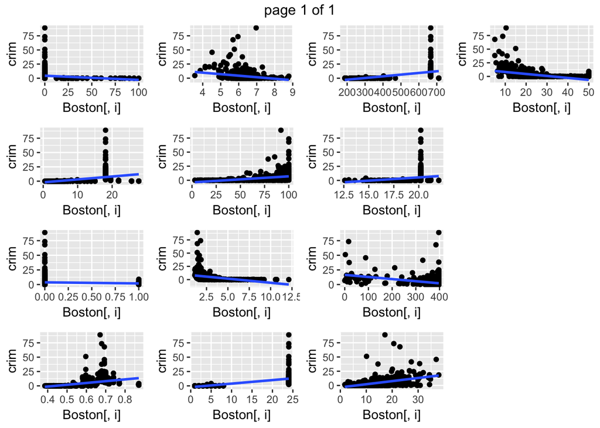

```r
make_plots <- function(i){
  p<- ggplot(data=Boston,aes(y=crim,x=Boston[,i])) + geom_point() + geom_smooth(method='lm',se=F)
  return(p)
}
l <- lapply(2:14,make_plots)
marrangeGrob(l,ncol=4,nrow=4)
```

2. Fit a multiple regression model to predict the response using all of the predictors. Describe your results. For which predictors can we reject the null hypothesis $H_0 : \beta_j = 0$?

```r
lm.full <- lm(crim~.,data=Boston)
sumf <- summary(lm.full)
ps <- coef(sumf)
cat("The predictors for which we can reject the null are",names(which(ps[,4] < 0.05)),sep=', ')
```

```
## The predictors for which we can reject the null are, (Intercept), zn, dis, rad, black, medv
```

3. How do your results from (a) compare to your results from (b)? Create a plot displaying the univariate regression coefficients from (a) on the x-axis, and the multiple regression coefficients from (b) on the y-axis. That is, each predictor is displayed as a single point in the plot. Its coefficient in a simple linear regression model is shown on the x-axis, and its coefficient estimate in the multiple linear regression model is shown on the y-axis.

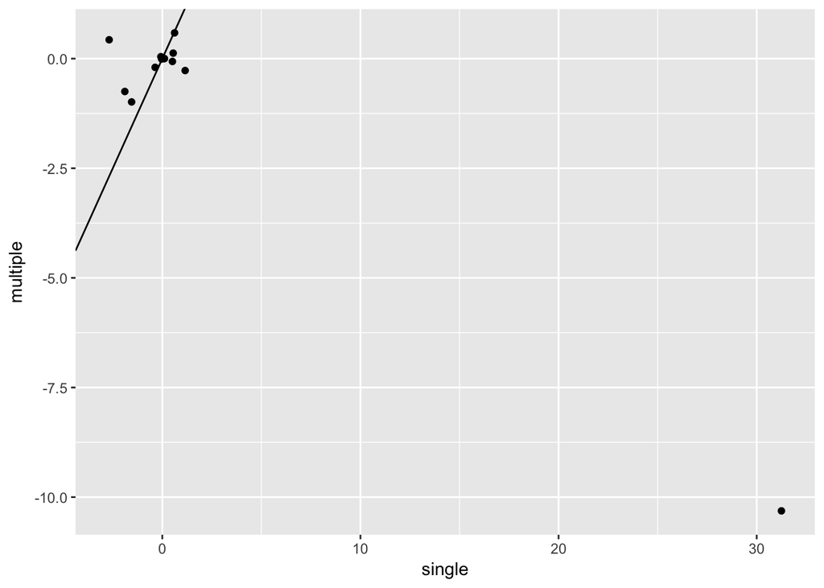

```r
get_single <- function(i){
  lm.out <- lm(crim~Boston[,i],data=Boston)
  return(coef(summary(lm.out))[2,1])
}
get_multiple <- function(i){
  lm.out <- lm(crim~.,data=Boston)
  return(coef(summary(lm.out))[i,1])
}
single <- sapply(2:14,get_single)
multiple <- sapply(2:14,get_multiple)
df <- data.frame(single = single, multiple=multiple)

ggplot(df,aes(y=multiple,x=single)) + geom_point() + geom_abline(slope=1,intercept=0)
```

4. Is there evidence of non-linear association between any of the predictors and the response? To answer this question, for each predictor X, fit a model of the form

$$Y = \beta_0 + \beta_1X +\beta_2X^2 +\beta_3X^3 +\epsilon.$$

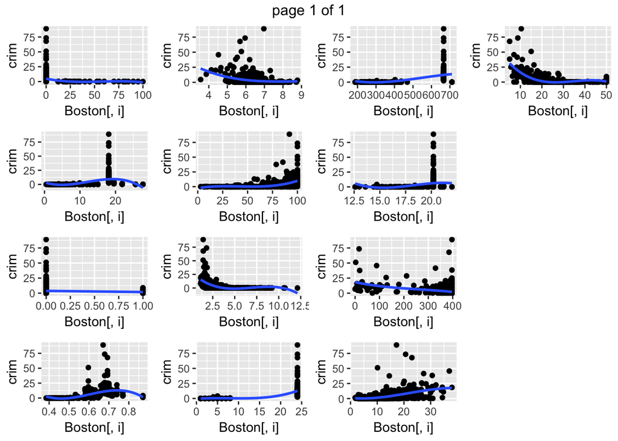

```r
make_plots_poly <- function(i){
  p <- ggplot(data=Boston,aes(y=crim,x=Boston[,i])) + geom_point() + geom_smooth(method='lm',formula=y~x+I(x^2)+I(x^3),se=F)
  return(p)
}
l2 <- lapply(2:14,make_plots_poly)
marrangeGrob(l2,ncol=4,nrow=4)
```

There appears to be non-linear relationships between some of the individual predictors and the dependent variable.